# Project: Train a Quadcopter How to Fly

#### Plot the Rewards (DDPG | Reward Function 2)

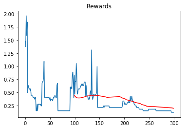

```python
rolling_mean= plot_rewards(DDPGrf2_reward, rolling_window=100)
```

#### Test the model (DDPG | Reward Function 2)

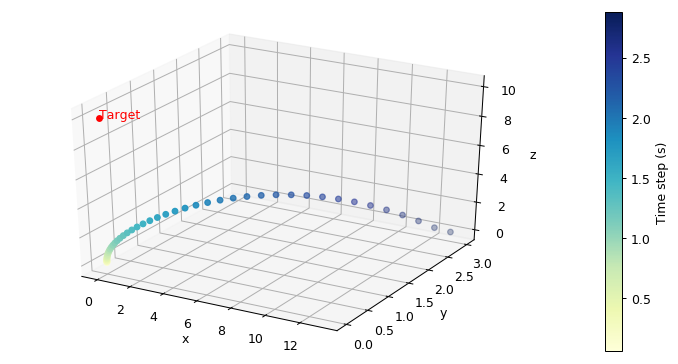

```
Reached highest Z:  3.2976610675779754
```

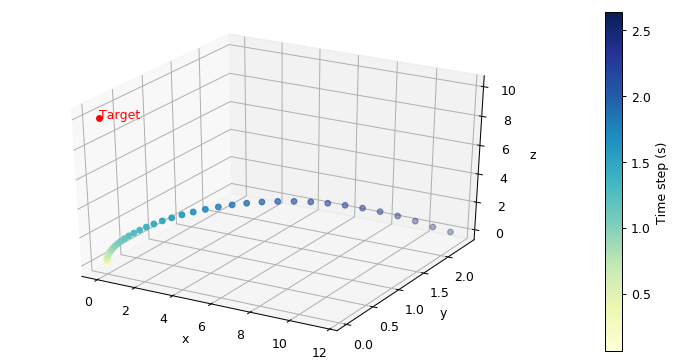

```
Reached highest Z:  2.7779542864488564
```

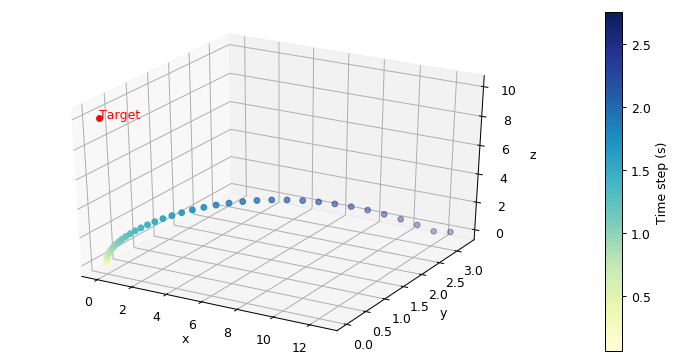

```
Reached highest Z:  2.9091490870727714
```

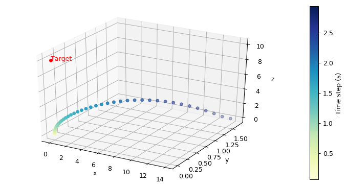

```
Reached highest Z:  3.415433532950806
```

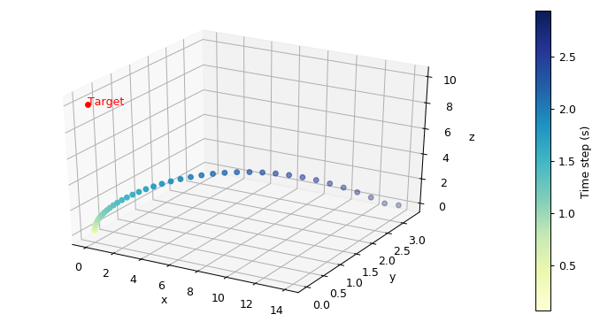

```
Reached highest Z:  3.3498519534721893
```

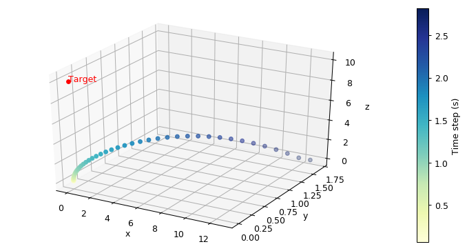

```
Reached highest Z:  3.178237047871482
```

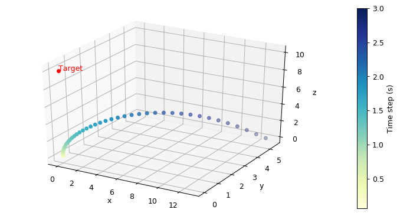

```
Reached highest Z:  3.580465497153473
```

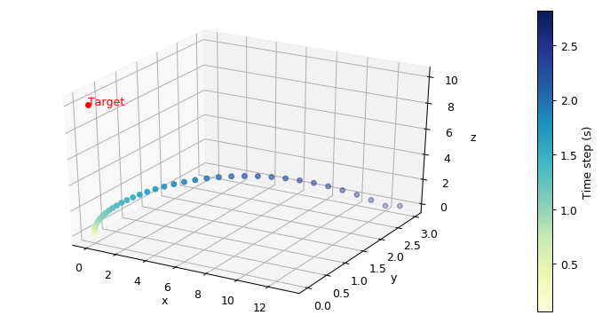

```
Reached highest Z:  3.0513179312997627
```

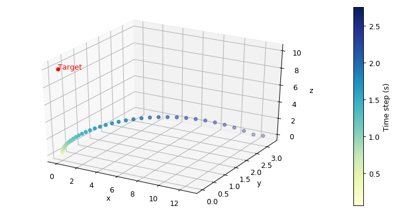

```
Reached highest Z:  2.907910019318007
```

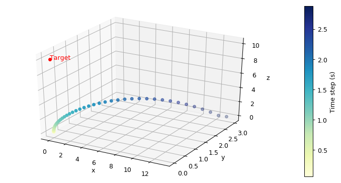

```
Reached highest Z:  3.228343706135675
```

```python
from takeoff import TakeOff
from agents.DDPG.DDPG import DDPG

task = TakeOff()
agent = DDPG(task)
ca_model_w = model_w[-1]

DDPG_test(agent, task, ca_model_w, 2)
```

## Reflections

**Question 1**: Describe the task that you specified in `task.py`. How did you design the reward function?

**Answer**:

Goal: The agent should be able to lift off from the ground and and reach the height of 10 in the z direction.

The position in the z direction is what I care about the most, so there is no reward or penalty regarding x and y direction. The main idea to shape the reward functions is to provide the agent postive rewards if it is climbing. Otherwise, the agent will receive negative reward if it is descending.

I have tried different reward functions and finally narrowed down to 2 options.

- *Option 1*

  ```
  if self.sim.pose[2] > old_pose[2]:
        reward = 1
        if  self.sim.pose[2] > self.target_pos[2]:
            reward = -0.05
    else:
        reward = -0.5
  ```

- *Option 2*

  ```
  if self.sim.pose[2] > old_pose[2]:
        reward = 0.02-.001*abs(z_distance_from_target) + .001*self.sim.pose[2]
    else:
        reward = 0.02-.001*abs(z_distance_from_target) - .0001
  ```

Option 1 is quite simple and straightforward without taking into account details.

Option 2 not only considers deviation from the z target in every time steps, but also provide constant rewards as long as the agent is kept flying.

**Question 2**: Discuss your agent briefly, using the following questions as a guide:

- What learning algorithm(s) did you try? What worked best for you?
- What was your final choice of hyperparameters (such as $\alpha$, $\gamma$, $\epsilon$, etc.)?
- What neural network architecture did you use (if any)? Specify layers, sizes, activation functions, etc.

**Answer**:

I have tried two agents, PolicySearch_Agent and DDPG.

*PolicySearch_Agent*: Initialize a weight matrix from a normal (Gaussian) distribution. Then update the weights based on the reward it received in every episode. I use tanh function to fit all state values into the interval between -1 and 1 before doing dot product with the weights matrix.

*DDPG*: An actor-critic method. The alogrithm is presented in this [paper](https://arxiv.org/pdf/1509.02971.pdf).

- **Architecture**

[figure not shown]

- **Hyperparameter**
  - Noise process: θ = 0.15; σ = 0.2
  - Replay memory: buffer_size = 100000; batch_size = 64
  - Algorithm parameters: γ = 0.95 (discount factor); τ = 0.001 (for soft update of target parameters)

In general, I follows the hyperparameters settings in the original [paper](https://arxiv.org/pdf/1509.02971.pdf) except changing γ from 0.99 to 0.95. In paper, the 2 hidden layers of the critic is 400 and 300 units respectively. In my project, I choose to use 32 and 64 units in the 2 hidden layers.

**Question 3**: Using the episode rewards plot, discuss how the agent learned over time.

- Was it an easy task to learn or hard?
- Was there a gradual learning curve, or an aha moment?
- How good was the final performance of the agent? (e.g. mean rewards over the last 10 episodes)

**Answer**:

It is not a easy job to learn because my reward function is not accurate enought to train the models.

In DDPG, it is highly possible that the reward function is not good enough to direct the agent to achieve the goal. Therefore, it ended up with not learning what we are expected. That's why in the reward plot, it tends to learn in the first 100 episodes and then stop gain rewards.

**Question 4**: Briefly summarize your experience working on this project. You can use the following prompts for ideas.

- What was the hardest part of the project? (e.g. getting started, plotting, specifying the task, etc.)
- Did you find anything interesting in how the quadcopter or your agent behaved?

**Answer**:

Crafting reward functions is the hardest part of the project for me.

Critic trains its network weights according to Q-value which is current reward plus discount factor times next state Q-value. Then Critic will provide its feedback to Actor and Actor updates its network weights based on the feedback. Therefore, if the reward function is not accurate enough, the critic will not predict the Q-value correctly. Actor receives poor quality of feedback which will result in choosing poor actions in next state. As a result, the agent performance will become worse after training.

Besides, there are many parameters such as angular velocity, gravity ,linear drag, etc. should be taken into account to shape better reward functions. But it may need to use more professional parameter estimation techniques and have further knowledge of drone physics.

The most interesting part to train the agent is to realize how difficult to balance reward and penalty. If I penalize the agent too much , it will tend to end the episode soon to decrease the loss. However, if I give higher rewards for each time step, it may not help the agent to reach the goal even it receives really high rewards. After doing this project, I do realize how hard to train the agent in reinforcement learning.